# HW2

Theodoros Sofianos $ Pol Ribo Leon

December 7, 2018

### Getting the data 2003-01-01008-01-01

Here we have the companies that we chose.There are 4 companies for each GICS sector established in the statement from 2003-01-01 to 2008-01-01

Industrials:“CSX CSX Corp.”,“ITW Illinois Tool Works”,“LMT Lockheed Martin Corp.”,“UPS United Parcel Service”

Health Care:“BDX Becton Dickinson”,“PKI PerkinElmer”,“ZBH Zimmer Biomet Holdings”,“UNH United Health Group Inc.”

Consumer Discretionary:“BBY Best Buy Co. Inc.”,“LOW Lowe’s Cos.”,“GPS Gap Inc.”,“NKE Nike”

Energy:“DVN Devon Energy”,“SLB Schlumberger Ltd.”,“APA Apache Corporation”,“WMB Williams Cos.”

Financials:“GS Goldman Sachs Group”,“KEY KeyCorp”,“JPM JPMorgan Chase & Co.”,“C Citigroup Inc.”

Consumer Staples:“ADM Archer-Daniels-Midland Co”,“COST Costco Wholesale Corp.”,“WMT Walmart”,“WBA Walgreens Boots Alliance”

Telecommunications Services:“DIS The Walt Disney Company”,“T AT&T Inc.”,“IPG Interpublic Group”,“VZ Verizon Communications”

Information Technology:“HPQ HP Inc.”.“CSCO Cisco Systems”,“INTC Intel Corp.”,“ORCL Oracle Corp.”

Materials:“VMC Vulcan Materials”,“NUE Nucor Corp.”,“NEM Newmont Mining Corporation”,“EMN Eastman Chemical”

Utilities:“DUK Duke Energy”,“AEE Ameren Corp”,“NEE NextEra Energy”,“CMS CMS Energy”

```r
library("quantmod")
ticker_symbol <- c("CSX;ITW;LMT;UPS;BDX;PKI;ZBH;UNH;BBY;LOW;GPS;NKE;DVN;SLB;APA;WMB;GS;KEY;JPM;C;ADM;COST;WMT;WBA;DIS;T;IPG;VZ;HPQ;CSCO;INTC;ORCL;VMC;NUE;NEM;EMN;DUK;AEE;NEE;CMS")
Adj_Data <- new.env()
getSymbols(ticker_symbol, env=Adj_Data, from="2003-01-01", to= "2008-01-01")
```

```
##  [1] "CSX"  "ITW"  "LMT"  "UPS"  "BDX"  "PKI"  "ZBH"  "UNH"  "BBY"  "LOW"
## [11] "GPS"  "NKE"  "DVN"  "SLB"  "APA"  "WMB"  "GS"   "KEY"  "JPM"  "C"
## [21] "ADM"  "COST" "WMT"  "WBA"  "DIS"  "T"    "IPG"  "VZ"   "HPQ"  "CSCO"
## [31] "INTC" "ORCL" "VMC"  "NUE"  "NEM"  "EMN"  "DUK"  "AEE"  "NEE"  "CMS"
```

```r
#Procrisis_Adj_Data is the resulting object of merging all the closing adjusted prices for all the stocks. N of rows=1258 days (5 years)\ N of cols= 40 companies
ProCrisis_Adj_Data <- do.call(merge, eapply(Adj_Data, Ad))

#A=vector conatining all the stock names(for later use)
A<- as.vector(colnames(ProCrisis_Adj_Data))
```

### Addition of logs

Here it cointains the proces of filling in an empty matrix with the closing stock price for each company, we add logs to the division of t=1 between t=t-1 for each day

```r
#empty matrix
log_mat<- matrix(,nrow = nrow(ProCrisis_Adj_Data)-1,ncol = ncol(ProCrisis_Adj_Data))

#we convert ProCrisis_Adj_Data to a matrix for coding purposes.
test <- as.matrix(ProCrisis_Adj_Data)

#LOOP to fill the empty matrix. As the first day doesn-t have a previous day, we start the loop at day 2.(2:1258)
for (i in 2:1258) {
  for ( j in 1:40) {
    log_mat[i-1,j]<- (log(test[i,j]/test[i-1,j]))
  }
}
```

### Matrix of Sample Correlations

Creation of the correlation matrix(COR) between stocks(columns of log_mat)

```r
COR<- matrix(,nrow = 40,ncol = 40)
COR<-(cor(log_mat))
```

### BOOTSRAP

Implementation of the bootstrap procedure for B=1000

```r
n<- nrow(log_mat)
bsamp<- matrix(,nrow = nrow(log_mat),ncol = ncol(log_mat))
btheta<- matrix(,nrow = 40,ncol = 40)
B = 1000

#Vector where all the bootstrap samples are saved. cointains the matrices of correlations from the bootstrap sample
brep = c()

set.seed(1213)
for (b in 1:B){
  idx = sample(1:n, replace = T)
  bsamp = log_mat[idx,]
  #btheta is the correlation matrix of every bootstrap sample
  btheta<-cor(bsamp)
  #btheta is stored in brep
  brep[[b]]<- btheta
}
```

### DELTAS

Creation of the delta values for each bootstrap sample. For each bootstrap sample we define the bootstrap replicate of a simulataneous test statistics

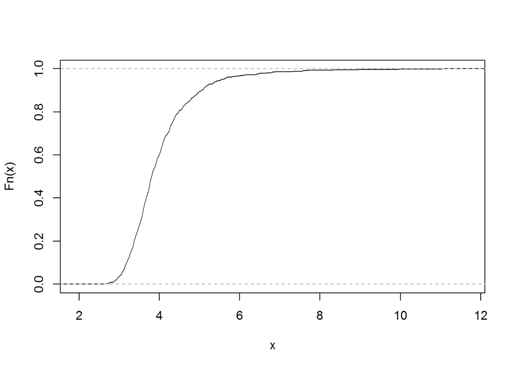

```r
deltas <-c()

for (i in c(1:B)){
  deltas <- append(deltas,sqrt(n)*max(abs(brep[[i]]-COR)))
}
#plot of the bootstrapped ECDF
Gstar = ecdf(deltas)
plot(Gstar,main="")
```

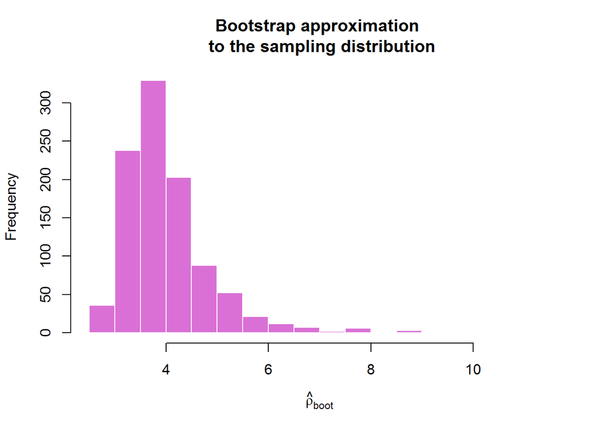

```r
hist(deltas, breaks = 25, col = "orchid", border = "white",
     xlab = expression(hat(rho)[boot]),
     main = "Bootstrap approximation \n to the sampling distribution")
```

###Confidence Intervals We create the sets of confidence intervals for the correlation between stocks for alpha=0.05. Conf_set_1 contains the lower confidence intervals Conf_set_2 contains the upper confidence intervals

```r
alpha = 0.05
ta = quantile(deltas,c(alpha/2, 1-alpha/2))
conf_set_1 <- COR-ta[2]/sqrt(n)
conf_set_2 <- COR+ta[1]/sqrt(n)

ta
```

```
##     2.5%    97.5%
## 2.943358 6.421626
```

### IGRAPH Graph

Each color represents a unique GICS

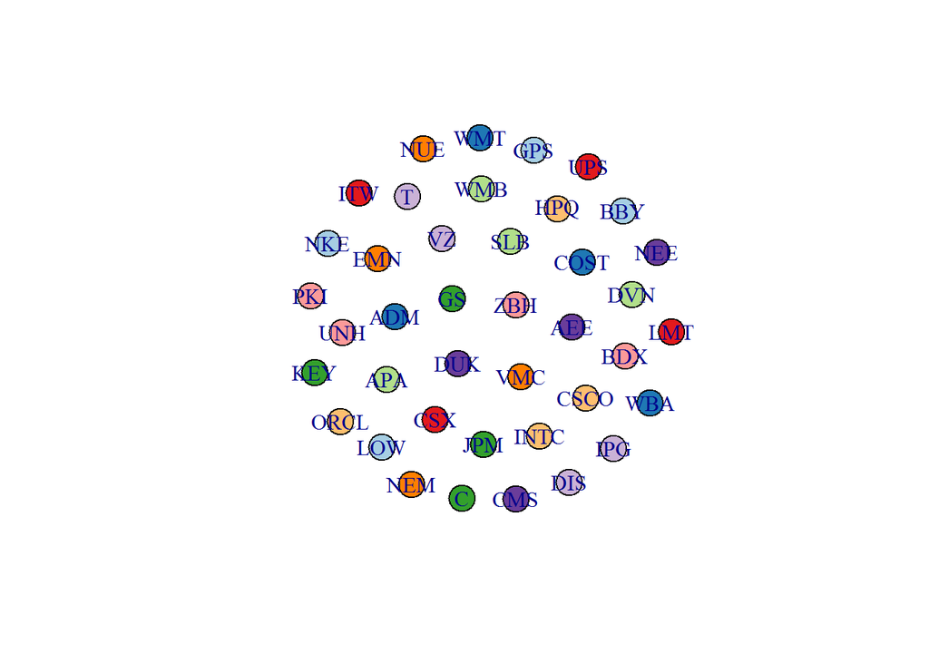

```r
library(energy)
library(igraph)
#vector containing all the names of the GICS for each company
GICS= c("Industrials","Industrials","Industrials","Industrials","Health Care","Health Care","Health Care","Health Care","Consumer Discretionary","Consumer Discretionary","Consumer Discretionary","Consumer Discretionary","Energy","Energy","Energy","Energy", "Financials","Financials","Financials","Financials", "Consumer Staples","Consumer Staples","Consumer Staples","Consumer Staples", "Telecommunications Services","Telecommunications Services","Telecommunications Services","Telecommunications Services", "Information Technology","Information Technology","Information Technology","Information Technology","Materials","Materials","Materials","Materials", "Utilities","Utilities","Utilities","Utilities")

#vector containing the sign of each company
stocks <- c("CSX","ITW","LMT","UPS","BDX","PKI","ZBH","UNH","BBY","LOW","GPS","NKE","DVN","SLB","APA","WMB","GS","KEY","JPM","C","ADM","COST","WMT","WBA","DIS","T","IPG","VZ","HPQ","CSCO","INTC","ORCL","VMC","NUE","NEM","EMN","DUK","AEE","NEE","CMS")

g<-make_empty_graph(length(stocks))
for(i in 1:length(V(g))){
  V(g)$name[i]=stocks[i]
  g<-set.vertex.attribute(g,"group", stocks[i], GICS[i])
}

require(RColorBrewer)
pal <- brewer.pal(length(unique(V(g)$group)),"Paired")
plot(g, vertex.color=pal[as.numeric(as.factor(vertex_attr(g,"group")))])
```

###Marginal Correlation Matrix for epsilon=0.15

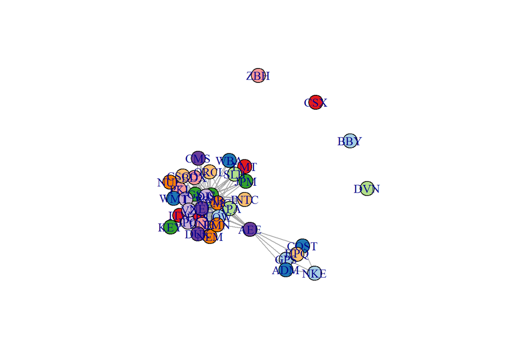

```r
g<-make_empty_graph(length(stocks))
for(i in 1:length(V(g))){
  V(g)$name[i]=stocks[i]
  g<-set.vertex.attribute(g,"group", stocks[i], GICS[i])
}
ε = 0.15

#we use the following for loops so that wedon't take the same pair of correlations two times
for (i in 1:39){
  for (j in (i+1):40){
    #if the intersection of the upper and lower confidence intervals for a pair of stocks doesn't fall in the interval range of [-ε,+ε], we add an edge to that pair.
    if ( conf_set_1[i,j]>=ε |  conf_set_2[i,j]<= -ε){

          g=add.edges(g,c(stocks[i],stocks[j]))
          g=as.undirected(g)
    }
}
}
#plotting of the graph
plot(g, lwd= 6, vertex.color=pal[as.numeric(as.factor(vertex_attr(g,"group")))])
```

As we see in the graph above, for an ε of 0.15 or smaller, almost all the stocks have edges between them, due to the fact that their confidence intervals don’t fall in [-0.15,0.15] We appreciate that a main group cointaining almost all the stocks. There is another one with few stocks that semm to be not correlated at all, and the last one has a few stocks from the same GICS, dark blue Consumer Staples and light blue Consumer Discretionary. ###Marginal Correlation Matrix for epsilon=0.30

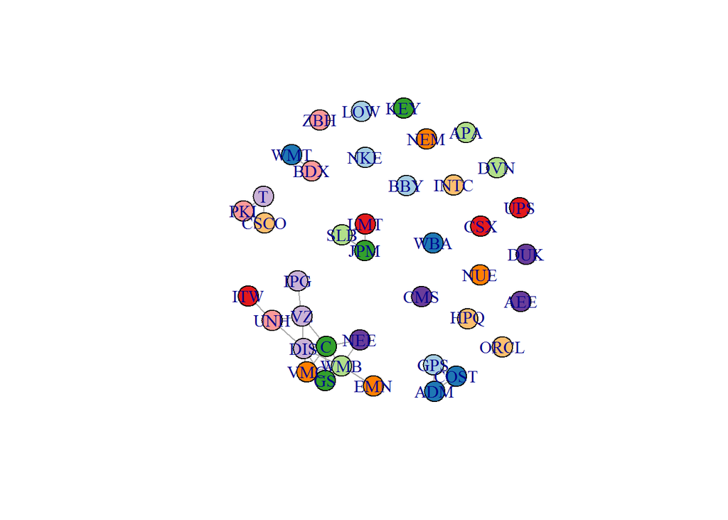

```r
g<-make_empty_graph(length(stocks))
for(i in 1:length(V(g))){
  V(g)$name[i]=stocks[i]
  g<-set.vertex.attribute(g,"group", stocks[i], GICS[i])
}
ε = 0.30

#
for (i in 1:39){
  for (j in (i+1):40){
    if ( conf_set_1[i,j]>=ε |  conf_set_2[i,j]<= -ε){

          g=add.edges(g,c(stocks[i],stocks[j]))
          g=as.undirected(g)
    }
}
}

plot(g, lwd= 6, vertex.color=pal[as.numeric(as.factor(vertex_attr(g,"group")))])
```

In this graph we appreciatte that we have less edges between stocks. The remaining edges state that there is a strong correlation between each other. Because of the nature of the stocks that we took in the first place, we can’t say that this result is a surprise. To shed more light on the issue, we only selected stocks from the same GICS, not subGICS. So, for example, inside the GICS consumer discretionary we have selected restaurant companies and shoe companies. Our belief is that if we only have selected restaurant companies(for example), our clusters would be brighter. Also, hat is why we see some edges between stocks from the same GICS but there are also eged with other stocks from other GICS. We checked the sample correlation for most of the stocks was realitevly low, for the reasons mentioned. In conclusion, as the correlations were low, we expected that there would not be clustered based on GICS, and that is what happened pretty much.

### Marginal Correlation Matrix for epsilon=0.5

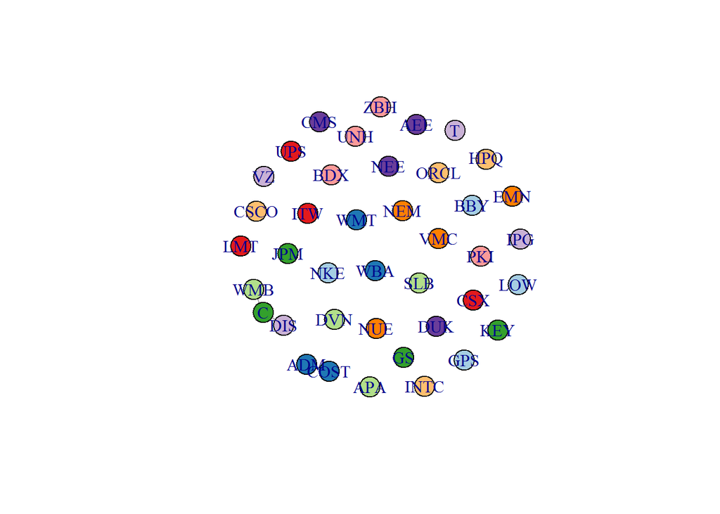

```r
g<-make_empty_graph(length(stocks))
for(i in 1:length(V(g))){
  V(g)$name[i]=stocks[i]
  g<-set.vertex.attribute(g,"group", stocks[i], GICS[i])
}
ε = 0.5

for (i in 1:39){
  for (j in (i+1):40){
    if ( conf_set_1[i,j]>=ε |  conf_set_2[i,j]<= -ε){

          g=add.edges(g,c(stocks[i],stocks[j]))
          g=as.undirected(g)
    }
}
}

plot(g, lwd= 6, vertex.color=pal[as.numeric(as.factor(vertex_attr(g,"group")))])
```

We see that with a bigger εof 0.5 the big cluster that included different stocks from different GICS has been reduced to a cluster of 3 stocks in which no one belongs to the same GICS. So, the reasons for clustering are not based on reasons that are not related to GICS. Even though that the cluster of dark blue consumer staples actually is based on GICS, our reasoning is that, as most of the clusters don’t fall into GICS, that stocks from the same sector don’t cluster together.

### Marginal Correlation Graph based on distance covariance

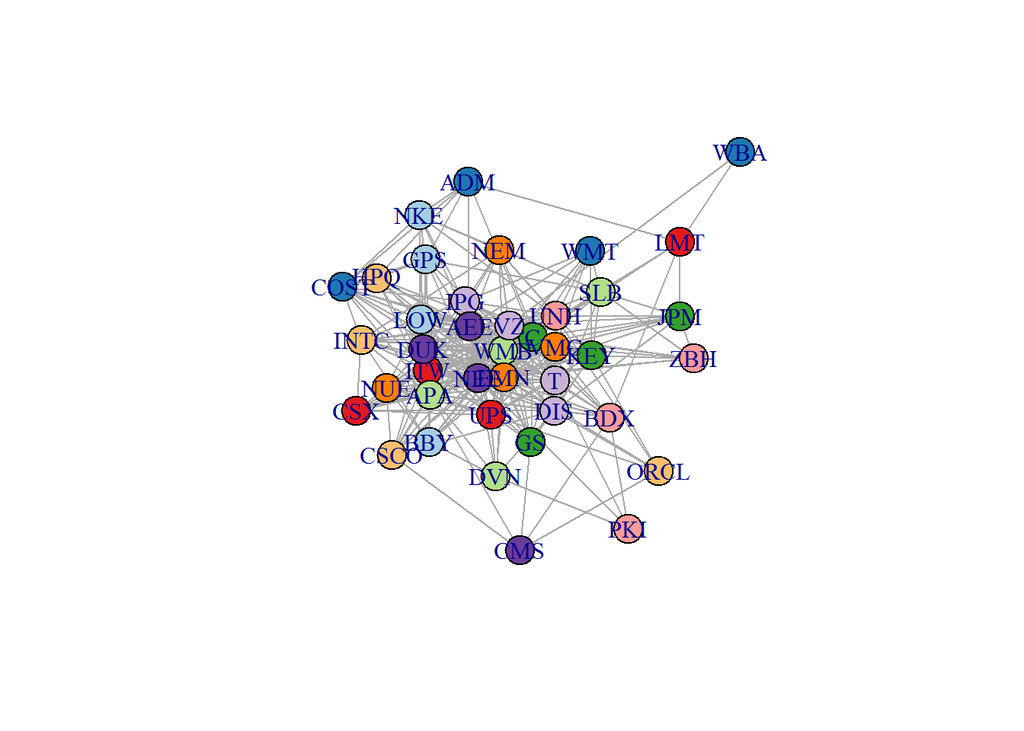

```r
g2<-make_empty_graph(length(stocks))
for(i in 1:length(V(g2))){
  V(g2)$name[i]=stocks[i]
  g2<-set.vertex.attribute(g2,"group", stocks[i], GICS[i])
}


for(i in 1:(ncol(log_mat)-1)){
  for (j in (i+1):ncol(log_mat)){
    #in this marginal correlation graph we get the pvalues from an independence test between the pairs of stocks, and if that pvalue is less than alpha=0.05, we reject H0 (H0=distance covariance=0) and we add an edge to that pair.
    testcase=indep.test(log_mat[,i],log_mat[,j],method = "dcov",R=1000,index = 0.001)
    #testcase[5] = pvalue
    if(testcase[5] <alpha){
      g2=add.edges(g2,c(stocks[i],stocks[j]))
      g2=as.undirected(g2)
    }

  }
}
plot(g2, lwd= 6, vertex.color=pal[as.numeric(as.factor(vertex_attr(g2,"group")))])
```

We observe in the above graph that there are too many stocks that have edges amongst them, no matter their sectors.This can be explained because there is a huge amount of pairs that we are testing, so randomness really affects our results. ###Marginal Correlation Graph based on distance covariance with BONFERRONI Correction

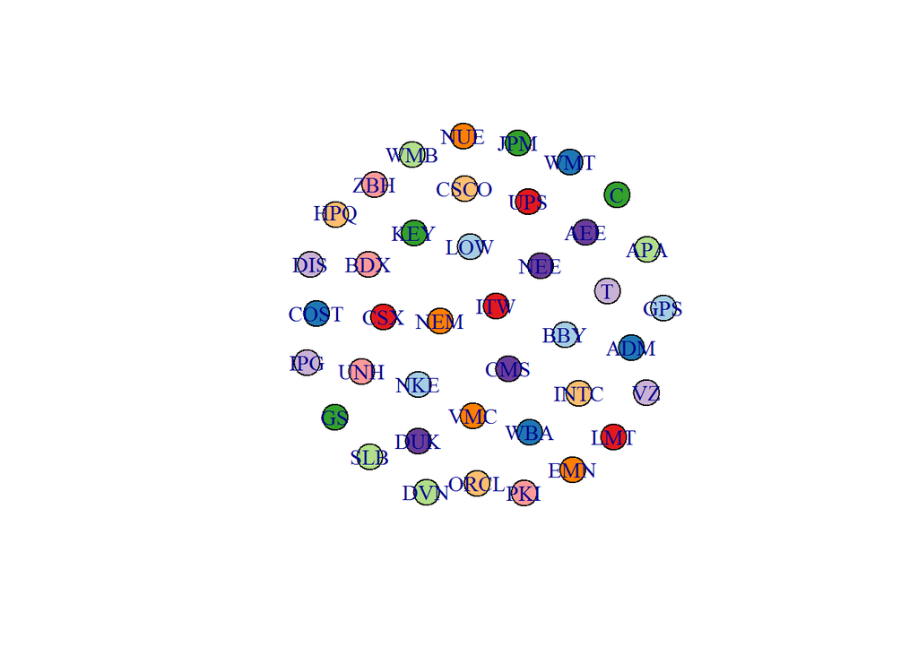

```r
g5<-make_empty_graph(length(stocks))
for(i in 1:length(V(g5))){
  V(g5)$name[i]=stocks[i]
  g5<-set.vertex.attribute(g5,"group", stocks[i], GICS[i])
}

#we add bonferroni correction to the previous loop
for(i in 1:(ncol(log_mat)-1)){
  for (j in (i+1):ncol(log_mat)){
    testcase=indep.test(log_mat[,i],log_mat[,j],method = "dcov",R=1000,index = 0.001)
    if (p.adjust(testcase[5],method = 'bonferroni',n = factorial(ncol(log_mat))/(factorial(38)*factorial(2))) <alpha){
      g5=add.edges(g5,c(stocks[i],stocks[j]))
      g5=as.undirected(g5)
    }

  }
}

plot(g5, lwd= 6, vertex.color=pal[as.numeric(as.factor(vertex_attr(g5,"group")))])
```

We were expecting boferonni to give us more solid results, but id didnt, because we see that in this graph we have no edges at all.The reason for this is we are making a false assumption in the very beggining of he homework. We have the adjusted prices for each stock during a period of many years, but we treat all the observations as IID variables,although they form a time-series, thus they are not independent.I think its logical to say that the value of a stock in any given day, it will affect its price in the next day also.

### Getting the data 2013-01-01018-01-01

Here we have the companies that we chose.There are 4 companies for each GICS sector established in the statement from 2013-01-01 to 2018-01-01

```r
library("quantmod")
ticker_symbol <- c("CSX;ITW;LMT;UPS;BDX;PKI;ZBH;UNH;BBY;LOW;GPS;NKE;DVN;SLB;APA;WMB;GS;KEY;JPM;C;ADM;COST;WMT;WBA;DIS;T;IPG;VZ;HPQ;CSCO;INTC;ORCL;VMC;NUE;NEM;EMN;DUK;AEE;NEE;CMS")
Adj_Data2 <- new.env()
getSymbols(ticker_symbol, env=Adj_Data2, from="2013-01-01", to= "2018-01-01")
```

```
##  [1] "CSX"  "ITW"  "LMT"  "UPS"  "BDX"  "PKI"  "ZBH"  "UNH"  "BBY"  "LOW"
## [11] "GPS"  "NKE"  "DVN"  "SLB"  "APA"  "WMB"  "GS"   "KEY"  "JPM"  "C"
## [21] "ADM"  "COST" "WMT"  "WBA"  "DIS"  "T"    "IPG"  "VZ"   "HPQ"  "CSCO"
## [31] "INTC" "ORCL" "VMC"  "NUE"  "NEM"  "EMN"  "DUK"  "AEE"  "NEE"  "CMS"
```

```r
AfterCrisis_Adj_Data <- do.call(merge, eapply(Adj_Data2, Ad))

nrow(AfterCrisis_Adj_Data)
```

```
## [1] 1259
```

```r
log_mat_2<- matrix(,nrow = nrow(AfterCrisis_Adj_Data)-1,ncol = ncol(AfterCrisis_Adj_Data))
# do the above using replicates
names2<- as.vector(colnames(AfterCrisis_Adj_Data))
```

### Addition of logs

```r
names2 <- as.matrix(AfterCrisis_Adj_Data)
for (i in 2:1259) {
  for ( j in 1:40) {
    log_mat_2[i-1,j]<- (log(names2[i,j]/names2[i-1,j]))
  }
}
```

### Matrix of Sample Correlations

```r
COR2<- matrix(,nrow = ncol(log_mat_2),ncol = ncol(log_mat_2))
COR2<-(cor(log_mat_2))
```

### BOOTSRAP

```r
n2<- nrow(log_mat_2)
bsamp2<- matrix(,nrow = nrow(log_mat_2),ncol = ncol(log_mat_2))
btheta2<- matrix(,nrow = nrow(COR2),ncol = ncol(COR2))
B = 1000
brep2 = c()
set.seed(1213)
for (b in 1:B){
  idx = sample(1:n, replace = T)
  bsamp2 = log_mat_2[idx,]
  btheta2<-cor(bsamp2)
  brep2[[b]]<- btheta2
}
```

### DELTAS

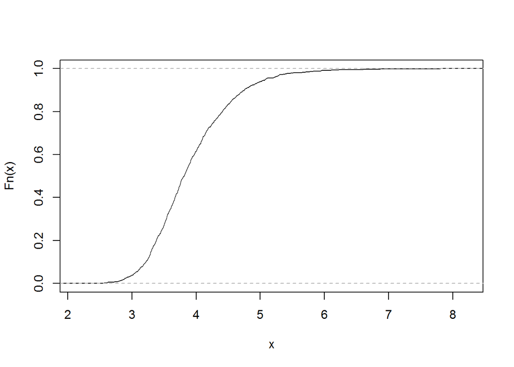

```r
deltas2 <-c()

for (i in c(1:B)){
  #deltas <- append(deltas,sqrt(n-1)*max(abs(brep[[i]]-COR[[i]])))
  deltas2 <- append(deltas2,sqrt(n2)*max(abs(brep2[[i]]-COR2)))
}
Gstar2 = ecdf(deltas2)
plot(Gstar2,main="")
```

[figure not shown]

```r
hist(deltas, breaks = 25, col = "orchid", border = "white",
     xlab = expression(hat(rho)[boot]),
     main = "Bootstrap approximation \n to the sampling distribution")
```

### Confidence Intervals

```r
alpha = 0.05
ta2 = quantile(deltas2,c(alpha/2, 1-alpha/2))
conf_set_3 <- COR2-ta[2]/sqrt(n2)
conf_set_4 <- COR2+ta[1]/sqrt(n2)
ta2
```

```
##     2.5%    97.5%
## 2.904651 5.384411
```

### IGRAPH Graph

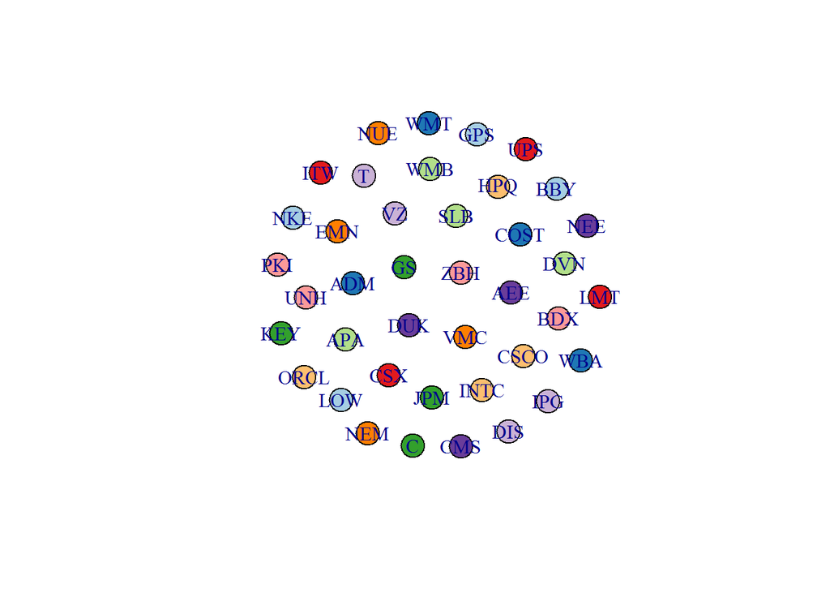

```r
g3<-make_empty_graph(length(stocks))
for(i in 1:length(V(g3))){
  V(g3)$name[i]=stocks[i]
  g3<-set.vertex.attribute(g3,"group", stocks[i], GICS[i])
}

plot(g3, vertex.color=pal[as.numeric(as.factor(vertex_attr(g3,"group")))])
```

### Marginal Correlation Matrix for epsilon=0.15

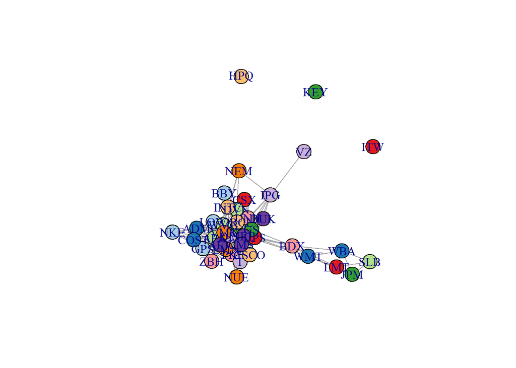

```r
g3<-make_empty_graph(length(stocks))
for(i in 1:length(V(g3))){
  V(g3)$name[i]=stocks[i]
  g3<-set.vertex.attribute(g3,"group", stocks[i], GICS[i])
}

ε = 0.15
for (i in 1:39){
  for (j in (i+1):40){
    if ( conf_set_3[i,j]>=ε |  conf_set_4[i,j]<= -ε){

      g3=add.edges(g3,c(stocks[i],stocks[j]))
      g3=as.undirected(g3)


    }
  }
}


plot(g3, lwd= 6, vertex.color=pal[as.numeric(as.factor(vertex_attr(g3,"group")))])
```

as in the data before crisis,we see that for an ε of 0.15 or smaller,almost all the stocks tend to have edges amongst them.There is no statistical sign that stocks from same GICS sector are clustered together. ###Marginal Correlation Matrix for epsilon=0.30

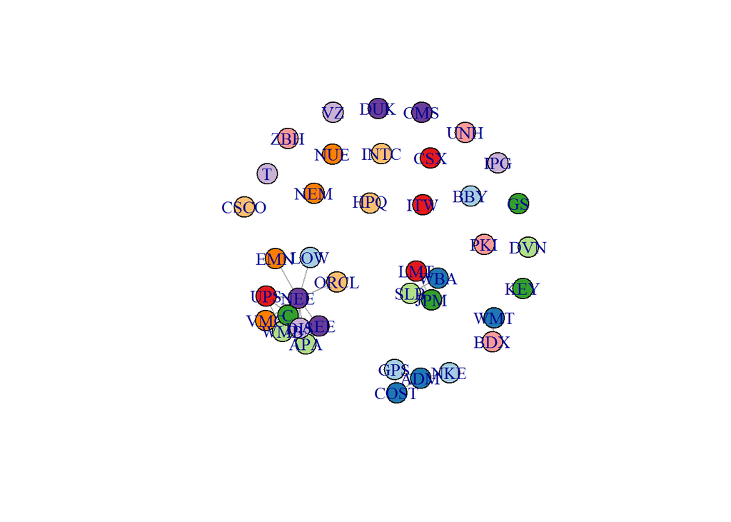

```r
g3<-make_empty_graph(length(stocks))
for(i in 1:length(V(g3))){
  V(g3)$name[i]=stocks[i]
  g3<-set.vertex.attribute(g3,"group", stocks[i], GICS[i])
}

ε = 0.3
for (i in 1:39){
  for (j in (i+1):40){
    if ( conf_set_3[i,j]>=ε |  conf_set_4[i,j]<= -ε){

      g3=add.edges(g3,c(stocks[i],stocks[j]))
      g3=as.undirected(g3)


    }
  }
}


plot(g3, lwd= 6, vertex.color=pal[as.numeric(as.factor(vertex_attr(g3,"group")))])
```

We notice that this graph is not very different from the graph we had for the same ε,with procrisis data. We observe that in this graph, some more stocks have been added to the clusters, compared to the previous graph, but yet again we see that there is not a ‘pattern’ that clusts stocks from same sector together.In this case, we can say that we dont have statstical evidence to claim that there is a difference in the correlation of stocks,before and after the crisis and neither we have for claiming that the correlation of stocks from different sectors after the crisis is bigger. ###Marginal Correlation Matrix for epsilon=0.5

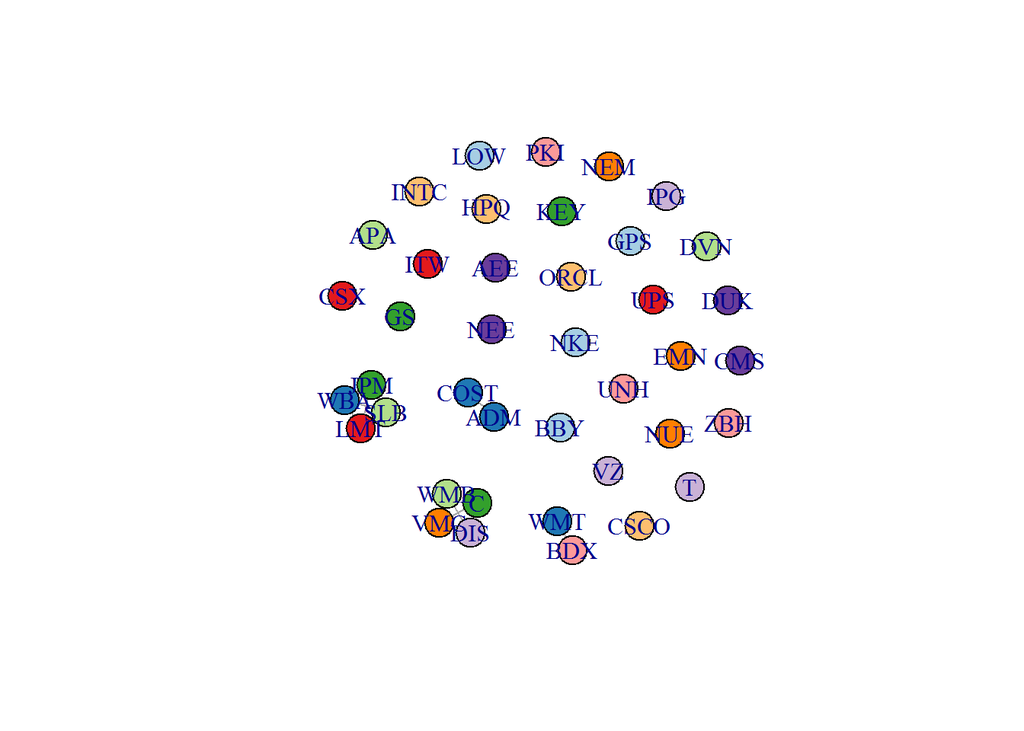

```r
g3<-make_empty_graph(length(stocks))
for(i in 1:length(V(g3))){
  V(g3)$name[i]=stocks[i]
  g3<-set.vertex.attribute(g3,"group", stocks[i], GICS[i])
}

ε = 0.5
for (i in 1:39){
  for (j in (i+1):40){
    if ( conf_set_3[i,j]>=ε |  conf_set_4[i,j]<= -ε){

      g3=add.edges(g3,c(stocks[i],stocks[j]))
      g3=as.undirected(g3)


    }
  }
}


plot(g3, lwd= 6, vertex.color=pal[as.numeric(as.factor(vertex_attr(g3,"group")))])
```

We notice again that the graph is similar with the one with procrisis data, for the same ε.Thus, we can conclude that based on our research, there is not statistically significance between our stocks, before and after crisis. The few changes that we see could be just by other unknown reasons. ###Marginal Correlation Graph based on distance covariance

```r
g4<-make_empty_graph(length(stocks))
for(i in 1:length(V(g4))){
  V(g4)$name[i]=stocks[i]
  g4<-set.vertex.attribute(g4,"group", stocks[i], GICS[i])
}

ncol(log_mat)
```

```
## [1] 40
```

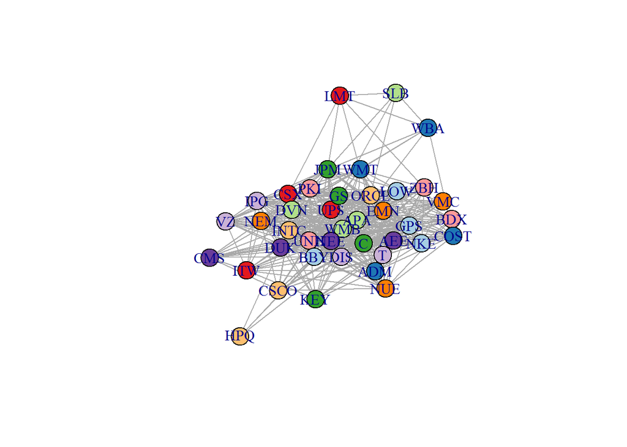

```r
for(i in 1:(ncol(log_mat_2)-1)){
  for (j in (i+1):ncol(log_mat_2)){
    testcase2=indep.test(log_mat_2[,i],log_mat_2[,j],method = "dcov",R=1000,index = 0.001)

    if(testcase2[5] <alpha){
      g4=add.edges(g4,c(stocks[i],stocks[j]))
      g4=as.undirected(g4)
    }

  }
}
plot(g4, lwd= 6, vertex.color=pal[as.numeric(as.factor(vertex_attr(g4,"group")))])
```

### Marginal Correlation Graph based on distance covariance with BONFERRONI Correction

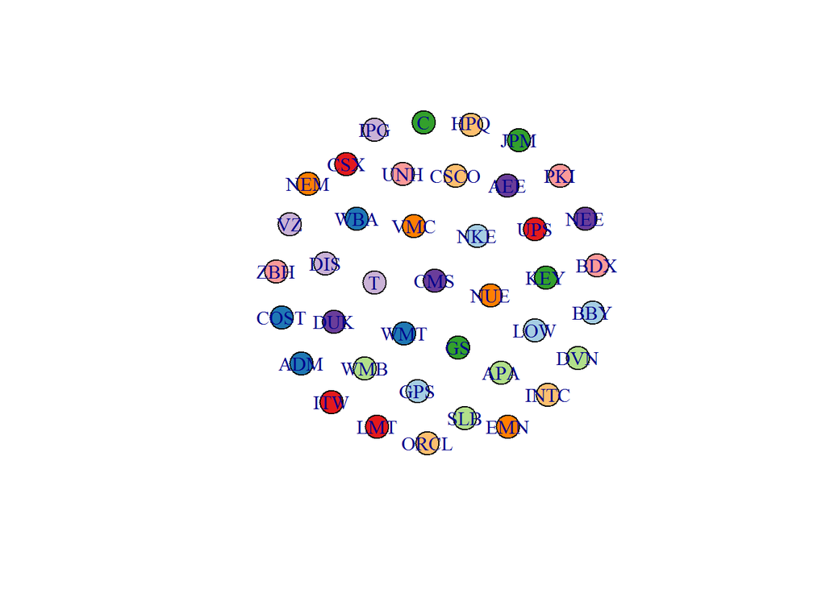

```r
g6<-make_empty_graph(length(stocks))
for(i in 1:length(V(g6))){
  V(g6)$name[i]=stocks[i]
  g6<-set.vertex.attribute(g6,"group", stocks[i], GICS[i])
}


for(i in 1:(ncol(log_mat_2)-1)){
  for (j in (i+1):ncol(log_mat_2)){
    testcase=indep.test(log_mat_2[,i],log_mat_2[,j],method = "dcov",R=1000,index = 0.001)
    if (p.adjust(testcase[5],method = 'bonferroni',n = factorial(ncol(log_mat_2))/(factorial(38)*factorial(2))) <alpha){
      g6=add.edges(g6,c(stocks[i],stocks[j]))
      g6=as.undirected(g6)
    }

  }
}

plot(g6, lwd= 6, vertex.color=pal[as.numeric(as.factor(vertex_attr(g6,"group")))])
```

So, we notice that we have the same problems in our marginal correlation graphs, based on distance, both for procrisis and after crisis data. Essentially, the conlusions we had are verified here again. We treated a time series object as individual observations, independent from each other, and thats why are graphs are practically the same with the previous ones, with and without the bonferonni correction.